# Movie Recommendation Model

Doug MacClure

5/1/2019

## Introduction

In this report, we analyze the movielens data set (found here: http://files.grouplens.org/datasets/movielens/ml-10m.zip) and construct various bias/effects-based recommendation algorithms using 90% of the movielens dataset. Other potential recommendation algorithms are discussed, and our approach using bias/effects instead is justified.

This project is done for the Data Science Capstone assignment via HarvardX. HarvardX has provided code up to creating training and validation datasets. The goal of this model is to create a recommendation model which predicts user-defined movie ratings evaluated on a validation dataset with root-mean squared error less than 0.87750.

To begin, perform the following steps: install (if necessary) and load the required packages to run the R code: caret, lubridate and tidyverse. Next, download the required data, and wrangle/coerce data for analysis. Finally, split the prepared data into training and validation datasets.

We begin our analysis of the data by noting which potential predictive variables we have to work with.

Note that the purpose of this model is to predict the rating a user would give for a given movie. Hence, we wish to build a model which predicts a movie rating given a userId and movieId. There are other predictors we can consider. Consider the following frequency histogram for number of movies rated per user.

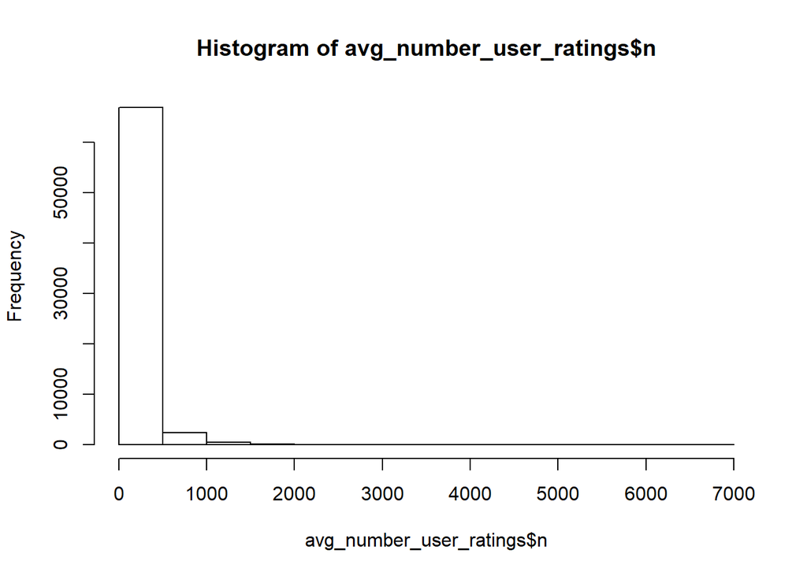

Most users rate less than 500 movies, and some users rate many movies. However, the average number of movies rated is:

```
## [1] 128.7968
```

Hence, we have enough data and variation in the data to build a movie recommendation model, which is further verified by considering the movie-rating distribution.

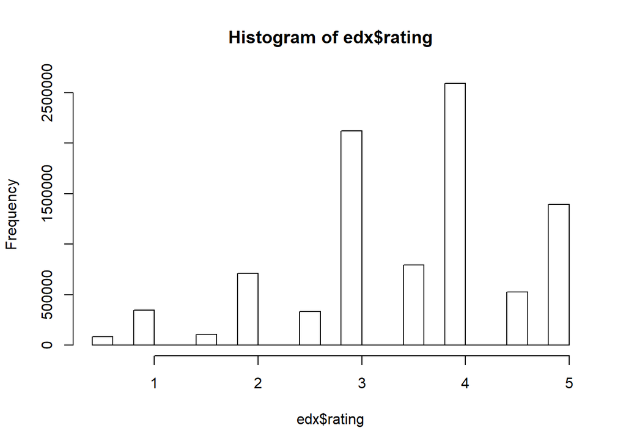

## Model Construction and Analysis

Now, note that the approach discussed here will utilize a random-effects approach, where the predictors are considered random variables, which depend on userId and movieId, as opposed to fixed quantities. The author has considered regression and classification models, but the structure of the data is inappropriate for such analysis, particularly on laptops, due to memory constraints.

We begin by considering movie and user effects on the variable we wish to predict: rating.

Now, lets analyze the following potential random-effects model:
$$Y_{u,i} = \mu + b_i + b_u,$$
where $\mu$ is a constant which represents the overall mean movie rating from all users for all movies. Here, $b_i$ is the movie and $b_u$ are random variables, dependent upon a user $u$ and movie $i$. To be more specific, $b_i$ is the average difference between a movie rating for movie $i$ and the overall average movie rating for all movies (i.e., the movie effect), while $b_u$ is the average difference between movies $i$ rated by user $u$ and the sum of $\mu$ and $b_i$ (i.e., the user effect).

Using R version 3.6, we have a RMSE score of 0.8655329. The author has observed other RMSE scores by running the code with R version 3.5.2. We can also determine how the model is performing by considering the residual distribution. Note that the mean is centered at zero and the distribution is approximately normal. This is a good indication that the model is neither over-estimating nor under-estimating on average.

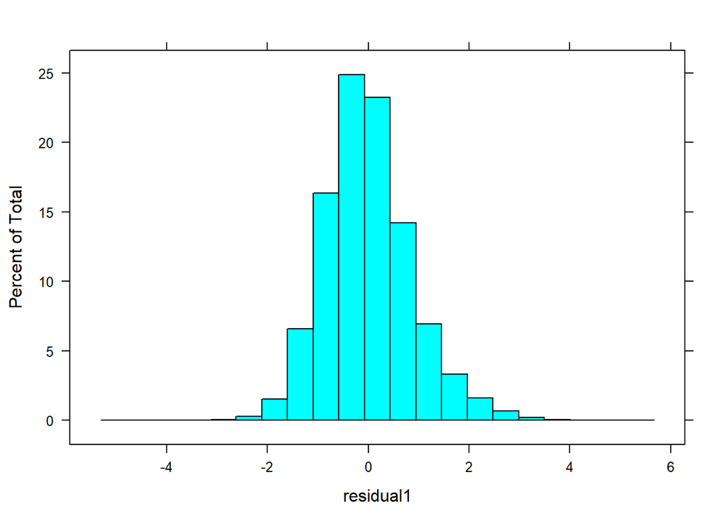

Next, we consider incorporating genres-effects into our random-effects model. Do we see an improvement in RMSE? Our new model is:
$$Y_{u,i} = \mu + b_i + b_u + g_{u,i}.$$
Observe the new residual distribution is essentially the same as before. Hence, we are starting to see diminishing returns in including more random-effects variables into our model.

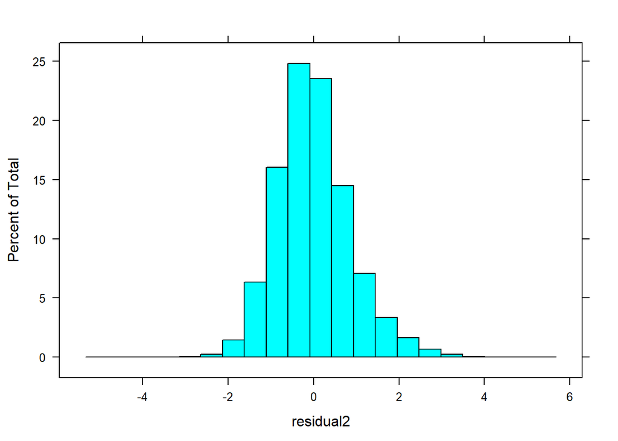

Despite diminishing returns, we do see a decrease in RMSE of $\approx 0.0003$. To finish, we incorporate time effects. However, before we do so, we need to note that timestamp is a number representing the number of minute since 01-01-1970 00:00. Note that we need to reduce the granularity of such a variable, since each particular timestamp will be associated with a small number of ratings, which we observe after computing the number of distinct timestamps and the total numer of observations we are considering.

| number_of_distinct_timestamps | number_of_observations |
| --- | --- |
| 6520453 | 9000061 |

Hence, the granularity of the time effect is by week. Further, observe that the new residual histogram is again essentially the same as before.

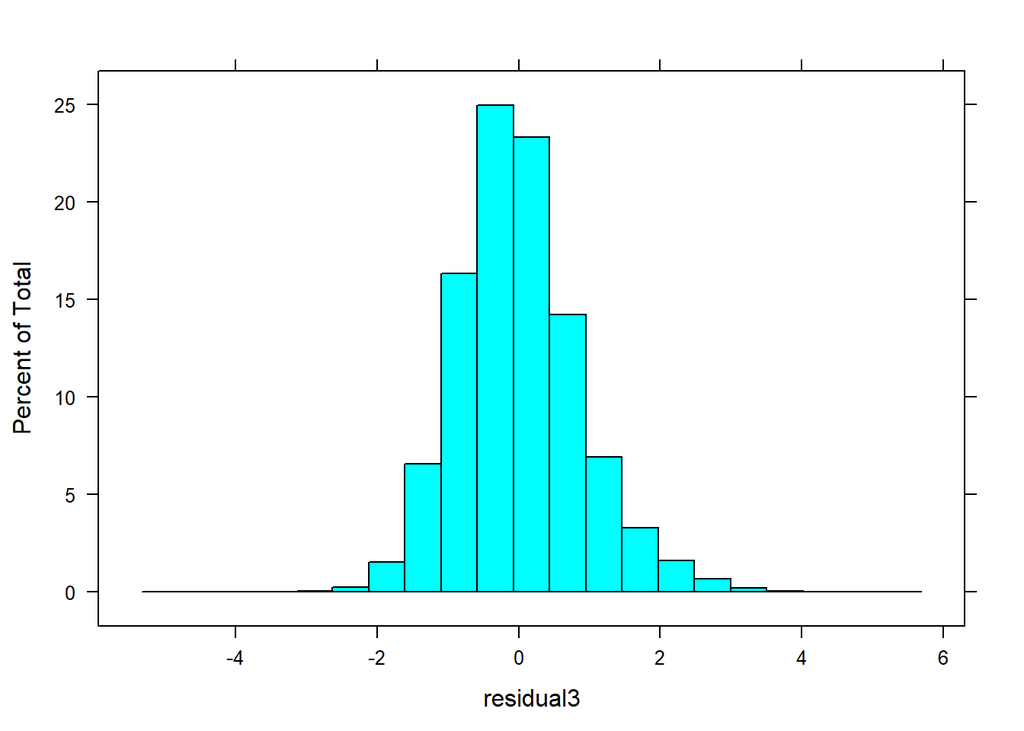

## Results

Finally, we compare the RMSE of each random-effects model to determine the best model, and if this model is satisfactory.

| method | RMSE |
| --- | --- |
| Movie + User Effects Model | 0.8655329 |
| Movie + User + Genre Effects Model | 0.8651946 |
| Movie + User + Genre + Time Effects Model | 0.8650986 |

We see that for $d_{u,i}$ denoting the random variable associated with the average rating of movie $u$ by user $i$ during a given week, the best performing model of the three is model 3:
$$Y_{u,i} \approx \mu + b_u + b_i + g_{u,i} + d_{u,i}.$$
Here, the RMSE is 0.8650986., which is well below the target RMSE of 0.87750.

Now, note that the author has considered generative model techniques as well. However, using Naive Bayes thus far has been unable to yield a model with RMSE below 1.1 and accuracy greater than 35%.

## Conclusion

In conclusion, we have shown that a random-effects modeling approach is most appropriate given the data we have to work with. We have generated a model which meets the initial goal of having the predictive power where the RMSE is below 0.8775.

There is room for further improvement in this model. The author would like to eventually try ensemble models, where regression and classification are done on smaller and more computable subsets.